# Chap_02

Leticia

2022-09-15

#Libraries

#2.1 Data - tsibble

Create a tsibbel object for time series, remember to set up the index, the time series variable.

```r
y <- tsibble(Year = 2015 : 2019,
             Observation = c(123, 39, 78, 52, 110),
             index = Year)
```

##Olympic Running

```r
olympic_running %>% distinct(Sex) #Shows the categories
```

```
## # A tibble: 2 x 1
##   Sex
##   <chr>
## 1 men
## 2 women
```

##Monthly dataset

```r
a10 <- PBS %>%
  filter(ATC2 == "A10") %>% #Rows
  select(Month, Concession, Type, Cost) %>% #Columns
  summarise(TotalC = sum(Cost)) %>%
  mutate(Cost = TotalC/1e6)
```

##Reading csv turn into tsibble

```r
prison <- readr::read_csv("https://OTexts.com/fpp3/extrafiles/prison_population.csv")
prison <- prison %>%
  mutate(Quarter = yearquarter(Date)) %>%
  select(-Date) %>%
  as_tsibble(key = c(State, Gender, Legal, Indigenous),
             index = Quarter)

prison
```

```
## # A tsibble: 3,072 x 6 [1Q]
## # Key:       State, Gender, Legal, Indigenous [64]
##    State Gender Legal    Indigenous Count Quarter
##    <chr> <chr>  <chr>    <chr>      <dbl>   <qtr>
##  1 ACT   Female Remanded ATSI           0 2005 Q1
##  2 ACT   Female Remanded ATSI           1 2005 Q2
##  3 ACT   Female Remanded ATSI           0 2005 Q3
##  4 ACT   Female Remanded ATSI           0 2005 Q4
##  5 ACT   Female Remanded ATSI           1 2006 Q1
##  6 ACT   Female Remanded ATSI           1 2006 Q2
##  7 ACT   Female Remanded ATSI           1 2006 Q3
##  8 ACT   Female Remanded ATSI           0 2006 Q4
##  9 ACT   Female Remanded ATSI           0 2007 Q1
## 10 ACT   Female Remanded ATSI           1 2007 Q2
## # ... with 3,062 more rows
```

#2.2 Plot - autoplot() ##melsyd_economy plot

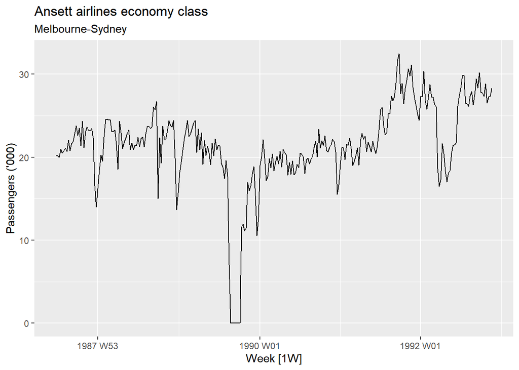

```r
melsyd_economy <- ansett %>%
   filter(Airports == "MEL-SYD", Class == "Economy") %>%
   mutate(Passengers = Passengers/1000)
 autoplot(melsyd_economy, Passengers) + #autoplot is created for time series
   labs(title = "Ansett airlines economy class",
        subtitle = "Melbourne-Sydney",
        y = "Passengers ('000)")
```

```r
melsyd_economy
```

```
## # A tsibble: 282 x 4 [1W]
## # Key:       Airports, Class [1]
##        Week Airports Class   Passengers
##      <week> <chr>    <chr>        <dbl>
##  1 1987 W26 MEL-SYD  Economy       20.2
##  2 1987 W27 MEL-SYD  Economy       20.2
##  3 1987 W28 MEL-SYD  Economy       20.0
##  4 1987 W29 MEL-SYD  Economy       21.0
##  5 1987 W30 MEL-SYD  Economy       20.5
##  6 1987 W31 MEL-SYD  Economy       20.8
##  7 1987 W32 MEL-SYD  Economy       21.1
##  8 1987 W33 MEL-SYD  Economy       20.7
##  9 1987 W34 MEL-SYD  Economy       22.1
## 10 1987 W35 MEL-SYD  Economy       20.8
## # ... with 272 more rows
```

##a10 plot

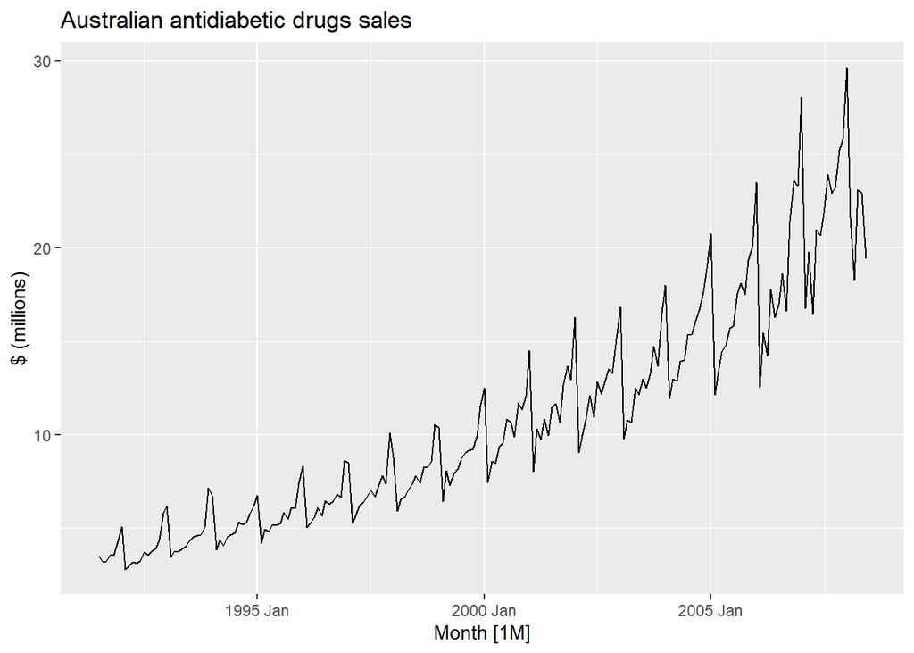

```r
autoplot(a10, Cost)+
  labs(y= "$ (millions)",
       title = "Australian antidiabetic drugs sales")
```

#2.3 Time series patterns

Patterns can be: Trend, seasonal and Cyclic.

## ggseason

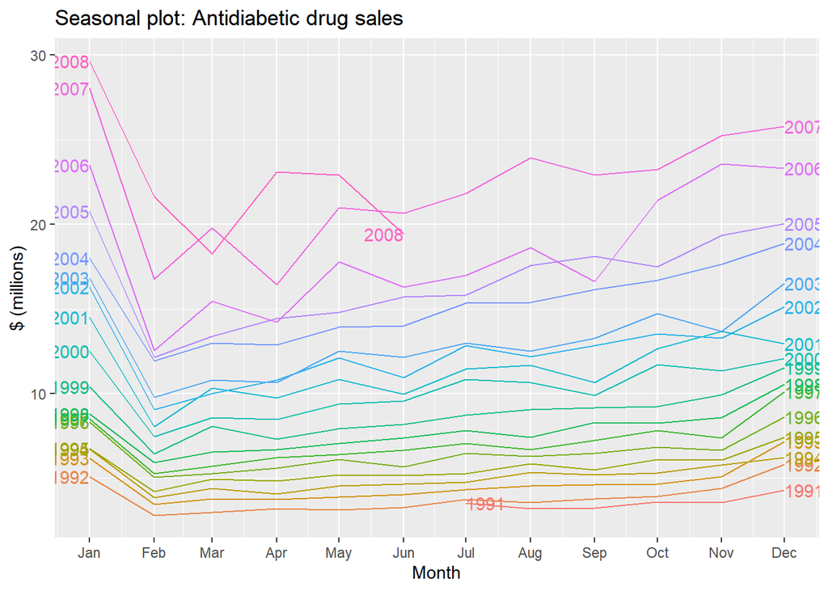

```r
a10 %>%
  gg_season(Cost, labels = "both") + #note
  labs(y = "$ (millions)",
       title = "Seasonal plot: Antidiabetic drug sales")
```

##vic_elec

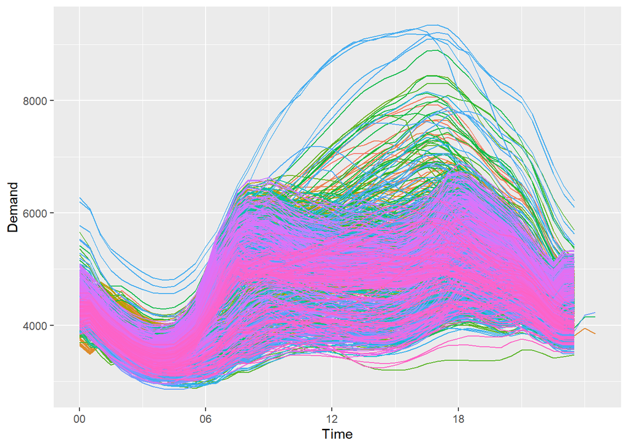

```r
vic_elec %>% gg_season(Demand, period = "day") +
   theme(legend.position = "none") #+
```

```r
#   labs(y="MWh", title="Electricity demand: Victoria")
```

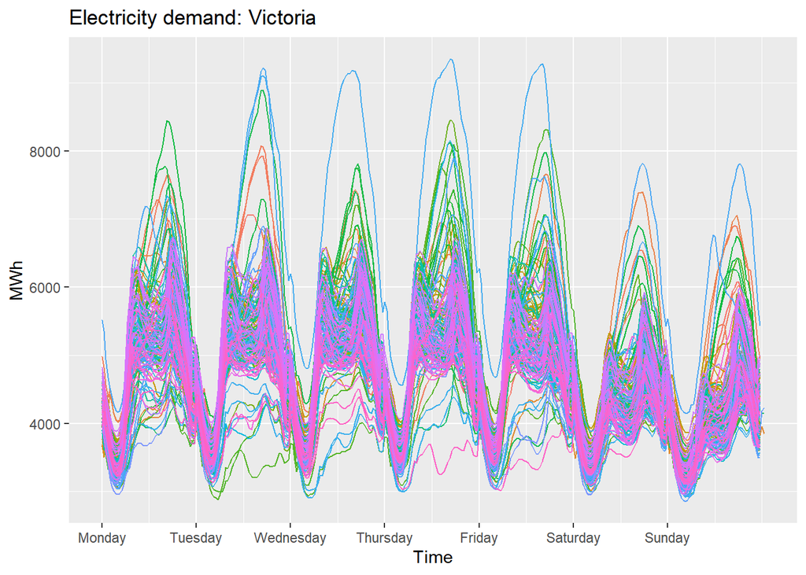

```r
vic_elec %>% gg_season(Demand, period = "week") +
  theme(legend.position = "none") +
  labs(y="MWh", title="Electricity demand: Victoria")
```

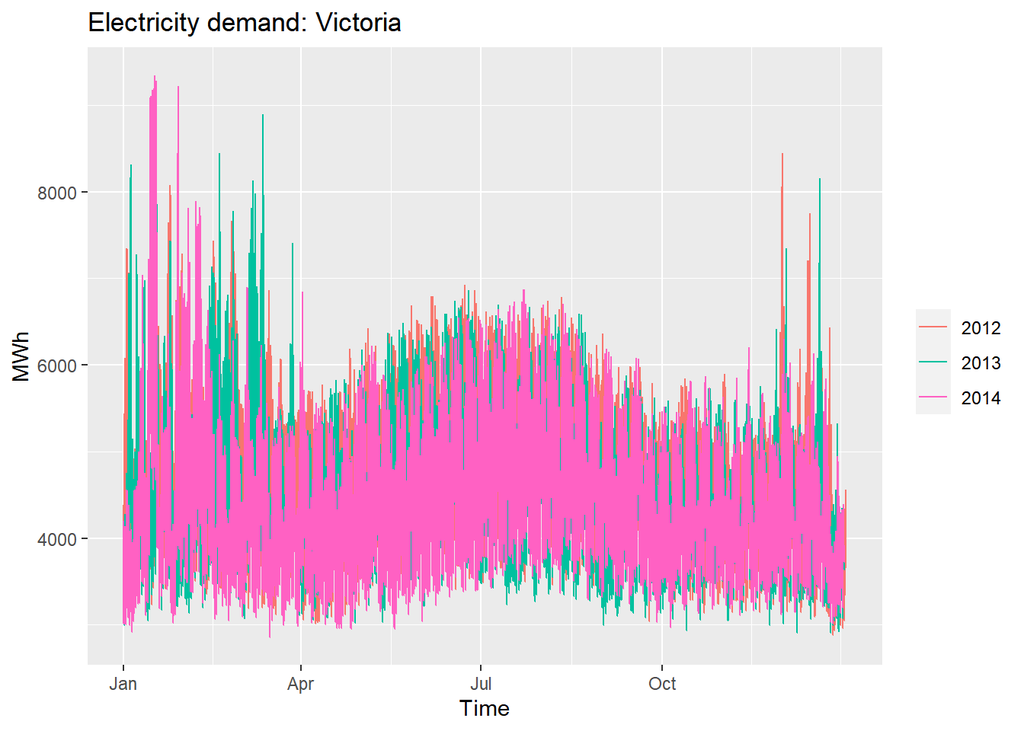

```r
vic_elec %>% gg_season(Demand, period = "year") +
  labs(y="MWh", title="Electricity demand: Victoria")
```

#2.5 Subseries

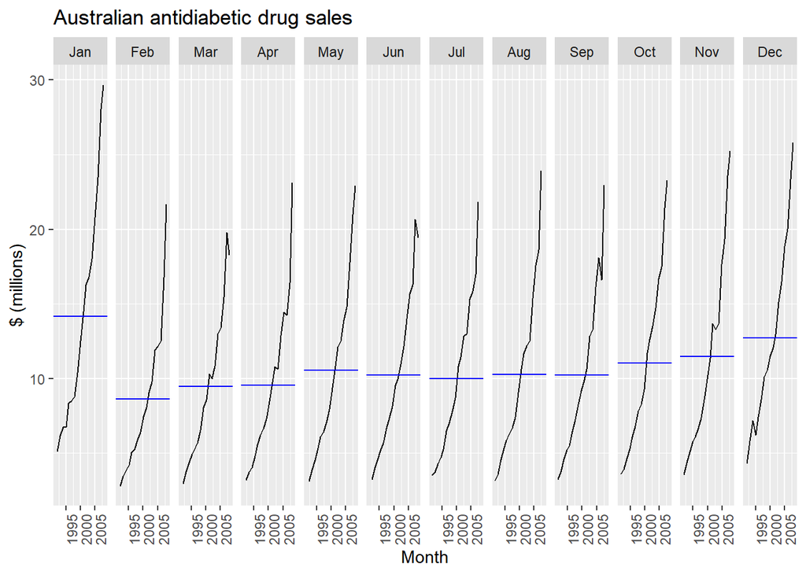

```r
a10 %>%
  gg_subseries(Cost) + #subseries already identified the year and month
  labs(
    y = "$ (millions)",
    title = "Australian antidiabetic drug sales"
  )
```

```r
#blue lines - means
```

##tourism

```r
holidays <- tourism %>%
  filter(Purpose == "Holiday") %>%
  group_by(State) %>%
  summarise(Trips = sum(Trips))

  holidays
```

```
## # A tsibble: 640 x 3 [1Q]
## # Key:       State [8]
##    State Quarter Trips
##    <chr>   <qtr> <dbl>
##  1 ACT   1998 Q1  196.
##  2 ACT   1998 Q2  127.
##  3 ACT   1998 Q3  111.
##  4 ACT   1998 Q4  170.
##  5 ACT   1999 Q1  108.
##  6 ACT   1999 Q2  125.
##  7 ACT   1999 Q3  178.
##  8 ACT   1999 Q4  218.
##  9 ACT   2000 Q1  158.
## 10 ACT   2000 Q2  155.
## # ... with 630 more rows
```

##autoplot tourism

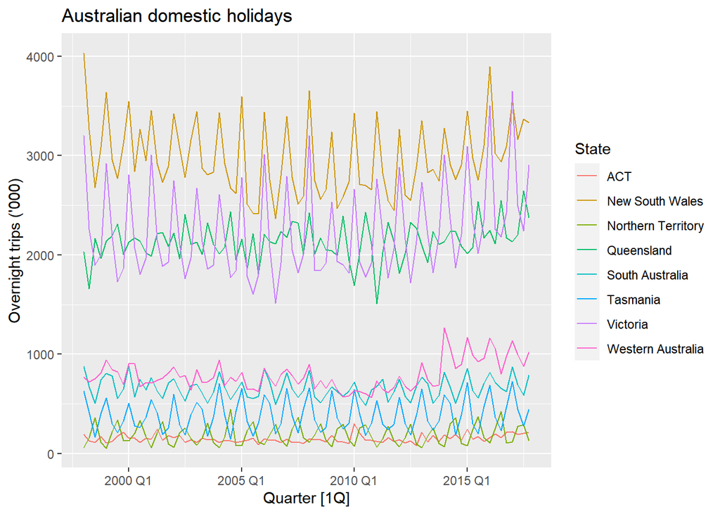

```r
autoplot(holidays, Trips) +
  labs(y = "Overnight trips ('000)",
       title = "Australian domestic holidays")
```

##season tourism

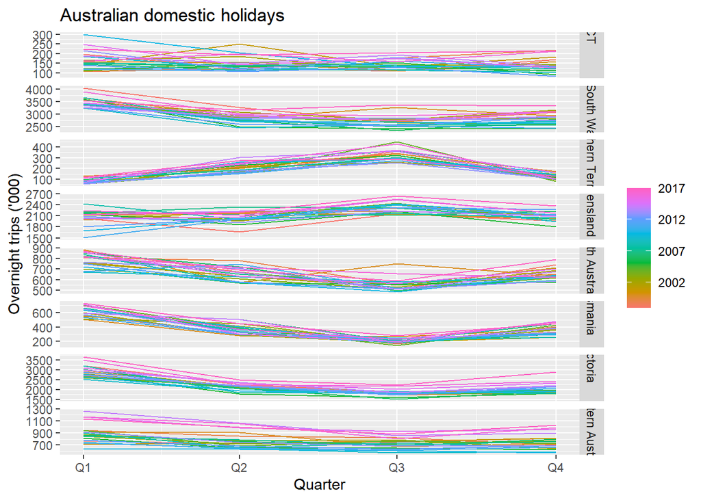

```r
gg_season(holidays, Trips) +
  labs(y = "Overnight trips ('000)",
       title = "Australian domestic holidays")
```

##Series for tourism

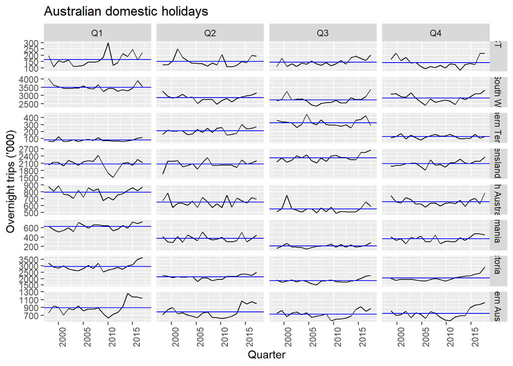

```r
holidays %>%
  gg_subseries(Trips) +
  labs(y = "Overnight trips ('000)",
       title = "Australian domestic holidays")
```

#2.6 Scatterplots

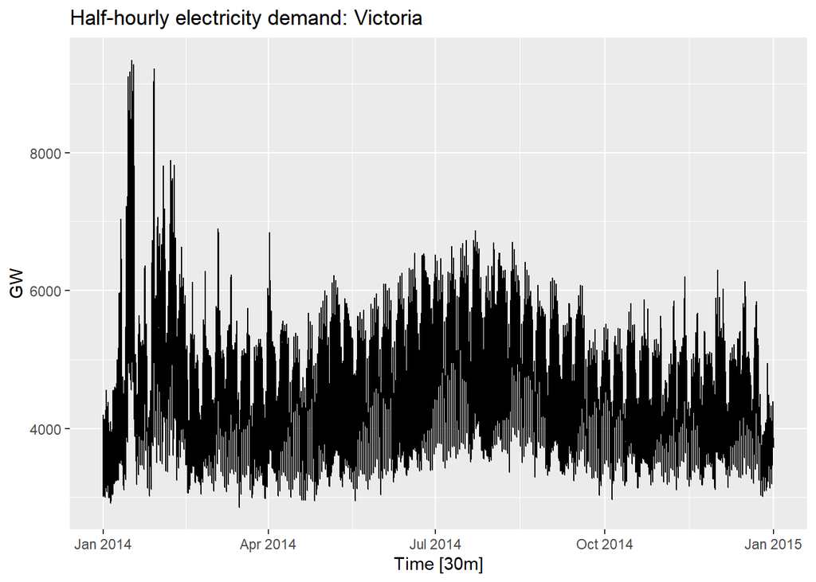

```r
vic_elec %>%
  filter(year(Time) == 2014) %>%
  autoplot(Demand) +
  labs(y = "GW",
       title = "Half-hourly electricity demand: Victoria")
```

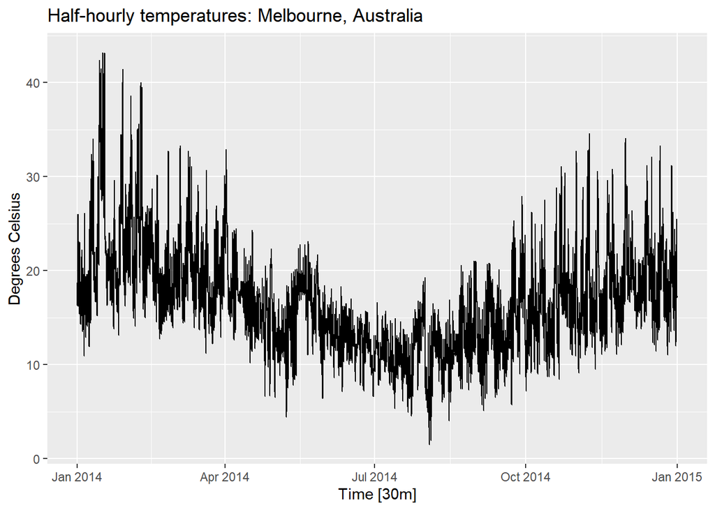

```r
vic_elec %>%
  filter(year(Time) == 2014) %>%
  autoplot(Temperature) +
  labs(
    y = "Degrees Celsius",
    title = "Half-hourly temperatures: Melbourne, Australia"
  )
```

##Correlation Plot

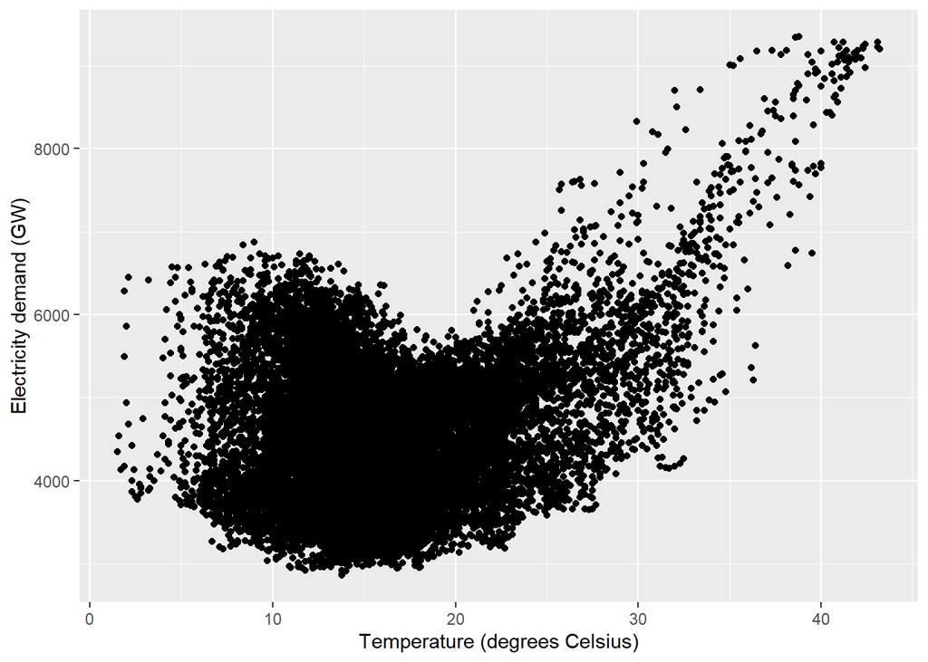

```r
vic_elec %>%
  filter(year(Time) == 2014) %>%
  ggplot(aes(x = Temperature, y = Demand)) +
  geom_point() +
  labs(x = "Temperature (degrees Celsius)",
       y = "Electricity demand (GW)")
```

##Scatterplot Matrices

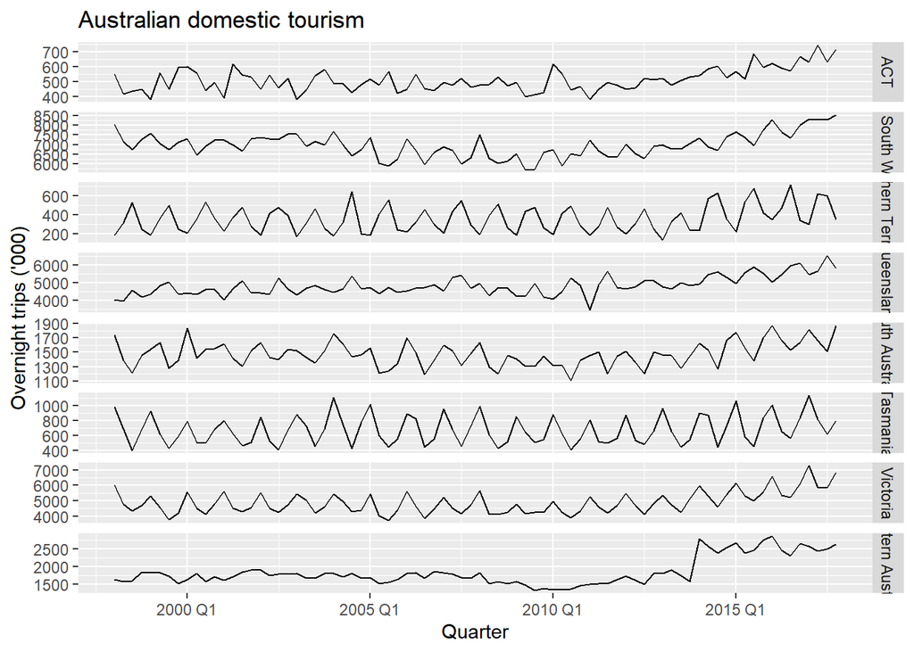

```r
visitors <- tourism %>%
  group_by(State) %>%
  summarise(Trips = sum(Trips))
visitors %>%
  ggplot(aes(x = Quarter, y = Trips)) +
  geom_line() +
  facet_grid(vars(State), scales = "free_y") +
  labs(title = "Australian domestic tourism",
       y= "Overnight trips ('000)")
```

##Relationships

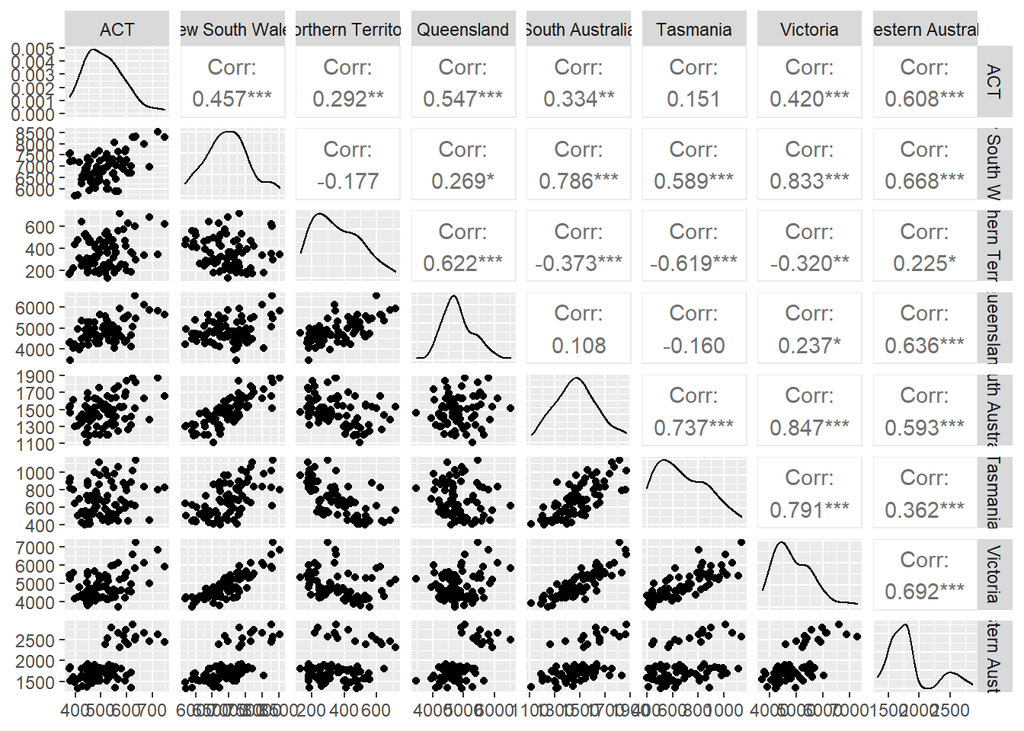

```r
visitors %>%
  pivot_wider(values_from=Trips, names_from=State) %>%
  GGally::ggpairs(columns = 2:9)
```

#2.7 Lag plots

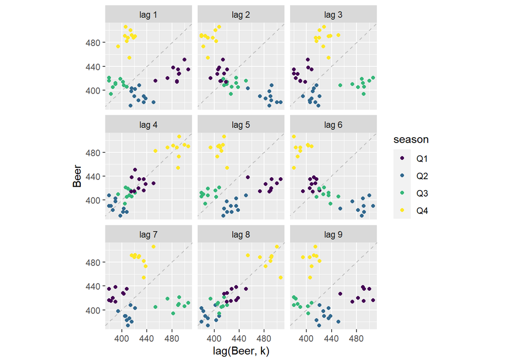

```r
recent_production <- aus_production %>%
  filter(year(Quarter) >= 2000)
recent_production %>%
  gg_lag(Beer, geom = "point") +
  labs(x = "lag(Beer, k)")
```

#2.8 Autocorrelation

ACF is a function to calculate the correlation between lagged values of a time series.

```r
recent_production %>% ACF(Beer, lag_max = 9)
```

```
## # A tsibble: 9 x 2 [1Q]
##     lag      acf
##   <lag>    <dbl>
## 1    1Q -0.0530
## 2    2Q -0.758
## 3    3Q -0.0262
## 4    4Q  0.802
## 5    5Q -0.0775
## 6    6Q -0.657
## 7    7Q  0.00119
## 8    8Q  0.707
## 9    9Q -0.0888
```

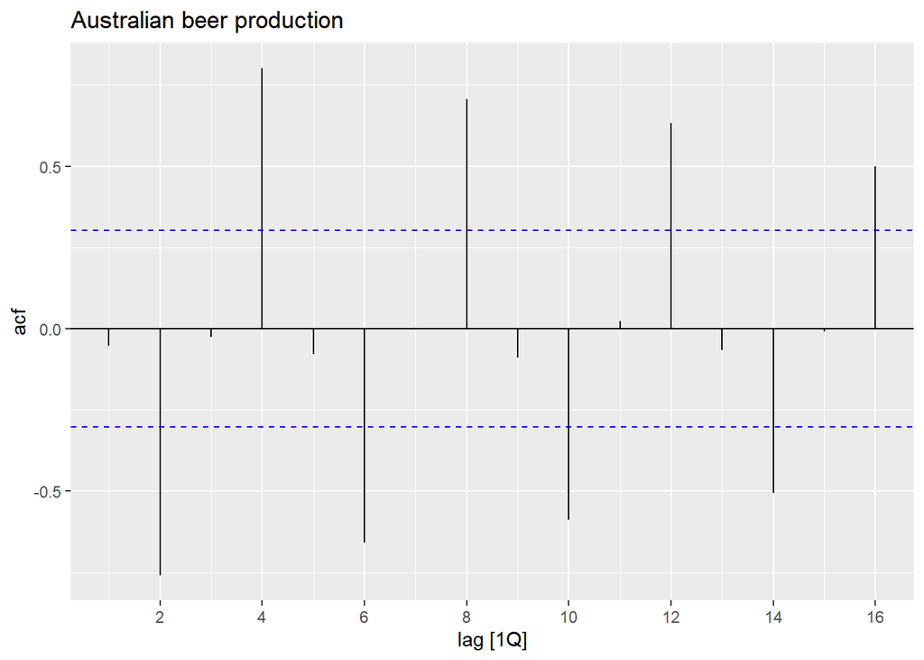

```r
recent_production %>%
  ACF(Beer) %>%
  autoplot() + labs(title="Australian beer production")
```

#2.9 White noise

This looks like a residual plot. Those are the NO AUTOCORRELATION.

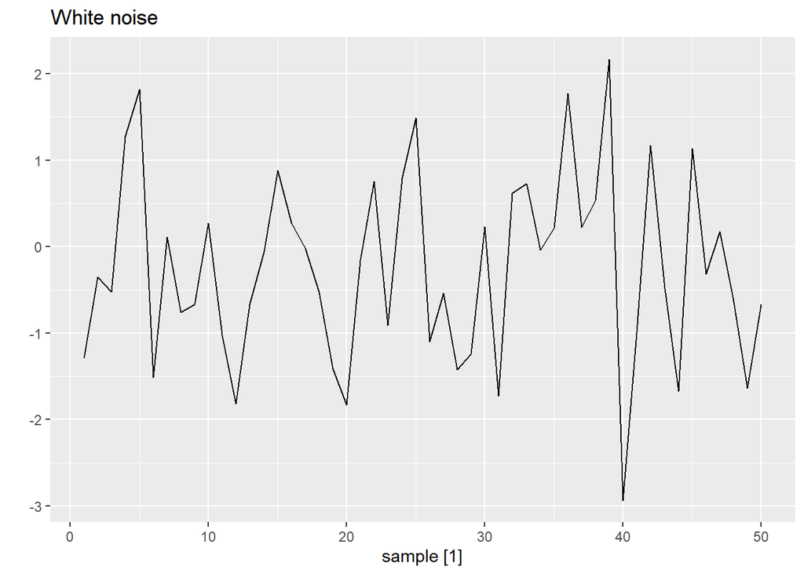

```r
set.seed(30)
y <- tsibble(sample = 1:50, wn = rnorm(50), index = sample) #create a new data set with random numbers, index is also being determined.
y %>% autoplot(wn) + labs(title = "White noise", y = "")
```

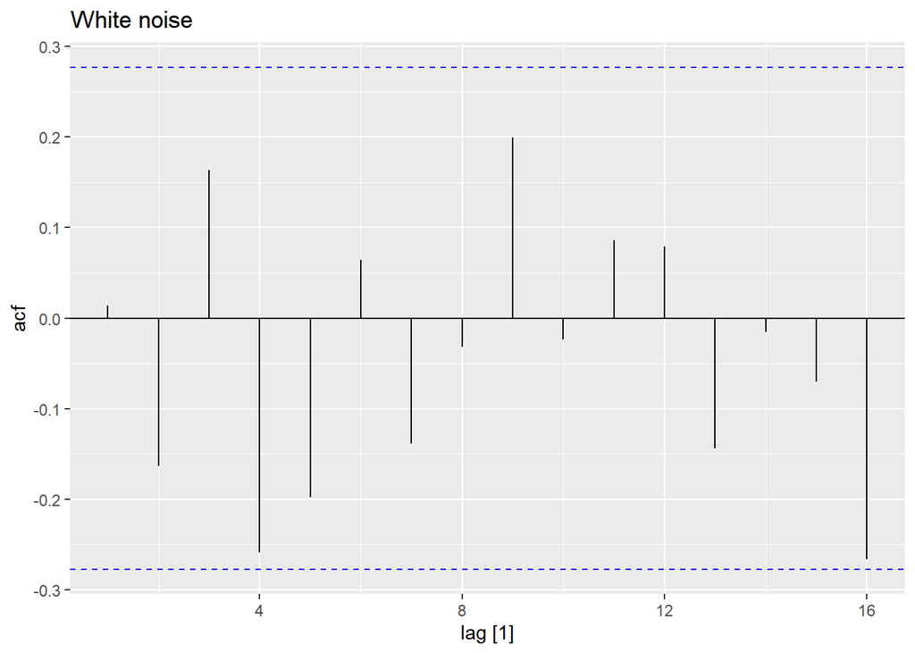

```r
y %>%
  ACF(wn) %>%
  autoplot() + labs(title = "White noise")
```

The black lines doesn’t touch the blue dashed lines and the ACF lies within ±2/√T where T is the length of the time. T=50 in this case = ±0.28. If its more than 5%, it could not be white noise. 2.10 Exercise 13

```r
dgoog <- gafa_stock %>%
  filter(Symbol == "GOOG", year(Date) >= 2018) %>%
  mutate(trading_day = row_number()) %>%
  update_tsibble(index = trading_day, regular = TRUE) %>%
  mutate(diff = difference(Close))

dgoog
```

```
## # A tsibble: 251 x 10 [1]
## # Key:       Symbol [1]
##    Symbol Date        Open  High   Low Close Adj_Close Volume trading_day   diff
##    <chr>  <date>     <dbl> <dbl> <dbl> <dbl>     <dbl>  <dbl>       <int>  <dbl>
##  1 GOOG   2018-01-02 1048. 1067. 1045. 1065      1065  1.24e6           1 NA
##  2 GOOG   2018-01-03 1064. 1086. 1063. 1082.     1082. 1.43e6           2 17.5
##  3 GOOG   2018-01-04 1088  1094. 1084. 1086.     1086. 1.00e6           3  3.92
##  4 GOOG   2018-01-05 1094  1104. 1092  1102.     1102. 1.28e6           4 15.8
##  5 GOOG   2018-01-08 1102. 1111. 1102. 1107.     1107. 1.05e6           5  4.71
##  6 GOOG   2018-01-09 1109. 1111. 1101. 1106.     1106. 9.02e5           6 -0.680
##  7 GOOG   2018-01-10 1097. 1105. 1096. 1103.     1103. 1.04e6           7 -3.65
##  8 GOOG   2018-01-11 1106. 1107. 1100. 1106.     1106. 9.78e5           8  2.91
##  9 GOOG   2018-01-12 1102. 1124. 1101. 1122.     1122. 1.72e6           9 16.7
## 10 GOOG   2018-01-16 1133. 1140. 1118. 1122.     1122. 1.58e6          10 -0.5
## # ... with 241 more rows
```

##a) The code was changed from date to a sequential number.

##b) ACF

```r
dgoog %>% ACF(diff, lag_max = 12) #monthly?
```

```
## # A tsibble: 12 x 3 [1]
## # Key:       Symbol [1]
##    Symbol   lag      acf
##    <chr>  <lag>    <dbl>
##  1 GOOG       1  0.0107
##  2 GOOG       2 -0.102
##  3 GOOG       3  0.109
##  4 GOOG       4  0.00840
##  5 GOOG       5 -0.0755
##  6 GOOG       6 -0.0850
##  7 GOOG       7  0.00635
##  8 GOOG       8 -0.143
##  9 GOOG       9 -0.0679
## 10 GOOG      10  0.110
## 11 GOOG      11 -0.119
## 12 GOOG      12 -0.0231
```

##c) white noise?

```r
a=2/sqrt(12)
a
```

```
## [1] 0.5773503
```

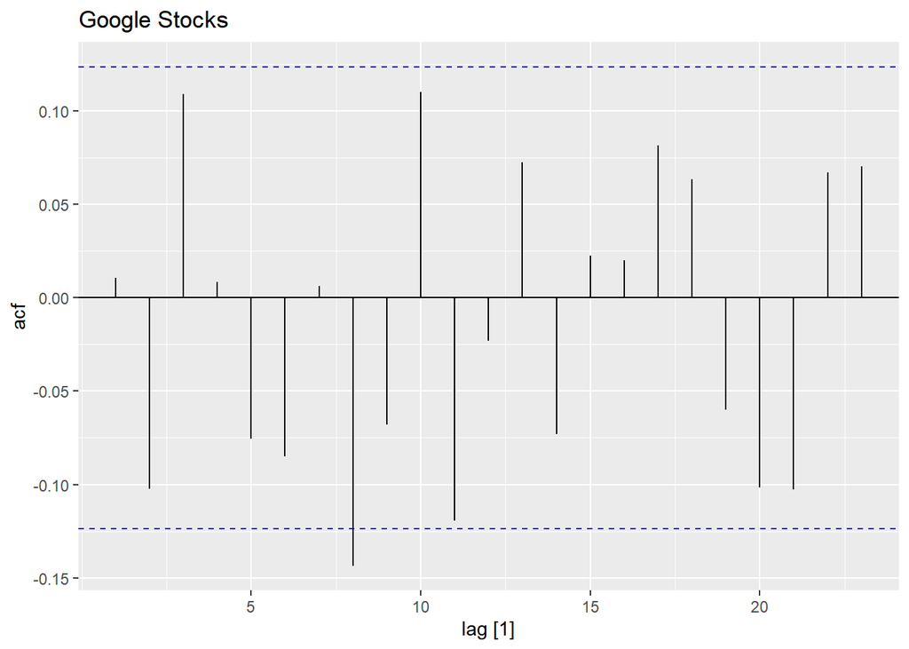

```r
dgoog %>%
  ACF(diff) %>%
  autoplot() + labs(title="Google Stocks")
```

#2.12 Questions

This tsibble contains 64 separate time series corresponding to the combinations of the 8 states, 2 genders, 2 legal statuses and 2 indigenous statuses. Each of these series is 48 observations in length, from 2005 Q1 to 2016 Q4. #I dont understand how they come up with this numbers.

Is the autoplot created based on ggplot2?

I don’t get difference between cyclic and seasonal. 2.3

vic_elec has this type of data s3: posix

How to decide the type of pattern? Based on researcher knowledge? 2.5 a10 example

I dont see where holiday is in the tourism dataset - Got it!

I didn’t understand the Lag plot - Lagged in production? why is this important? From this on I dont get it.

Lag_max =9 is the number of Quarters? what is k? I dont understand the correlation graph.

I still can not see the prediction, should we supose to know by now?